# Country Choropleths

You can create a choropleth of Countries with the function `country_choropleth`:

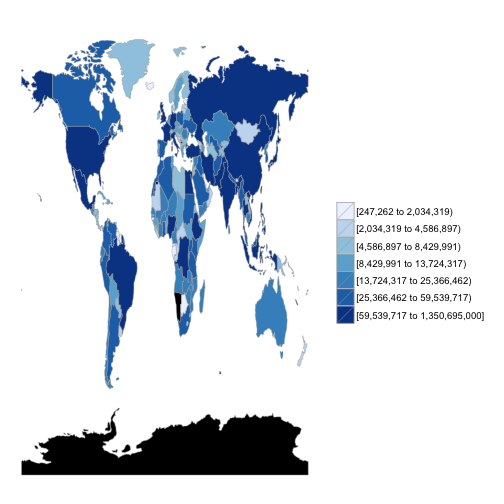

```r
library(choroplethr)

?df_pop_country
data(df_pop_country)

?country_choropleth
country_choropleth(df_pop_country)
```

As demonstrated above, the only required parameter to `country_choropleth` is a data.frame. You can see the optional parameters by typing `?country_choropleth`.

This map demonstrates another feature of choroplethr: regions for which no value is provided (what is the population of Antarctica?) appear, by default, as black.

# Data Requirements

The data.frame that you provide to `country_choropleth` must have one column named “region” and one column named “value”. Your entries for “region” must **exactly** match how regions are named in the map which choroplethr uses. These names are defined in the object `country.regions`:

```r
library(choroplethrMaps)

?country.regions
data(country.regions)
head(country.regions)
```

```
##        region iso2c
## 1 afghanistan    AF
## 2      angola    AO
## 3  azerbaijan    AZ
## 4     moldova    MD
## 5  madagascar    MG
## 6      mexico    MX
```

In order to use choroplethr, you must use the naming convention in the “region” column of country.regions. That is, you must use full names in all lowercase letters.

# Exploring Data

The `country_choropleth` function provides two parameters to facilitate exploring data: `buckets` and `zoom`. buckets defaults to 7, which means that there are 7 colors, and an equal number of states in each color. Valid values for buckets are integers betwen 1 and 7. If buckets is 1 then a continuous scale will be used. zoom defaults to NULL, which means that all states are shown. You can set it to be a vector of valid regions.

As an example, here is how you can use choroplethr to show the population of the US, Canada and Mexico.

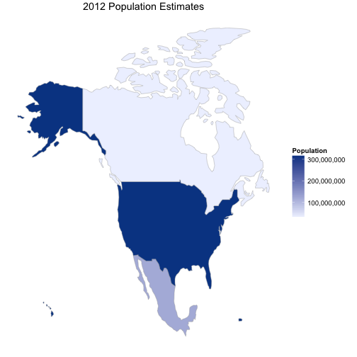

```r
country_choropleth(df_pop_country,
                 title   = "2012 Population Estimates",
                 legend  = "Population",
                 buckets = 1,
                 zoom    = c("united states of america", "mexico", "canada"))
```

# Advanced Options

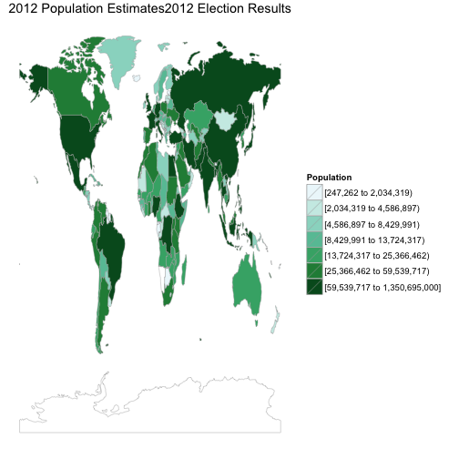

```r
library(ggplot2)

choro = CountryChoropleth$new(df_pop_country)
choro$title = "2012 Population Estimates2012 Election Results"
choro$ggplot_scale = scale_fill_brewer(name="Population", palette=2)
choro$render()
```